# Pennsylvania State restaurants rating predictions using Natural Language Processing (NLP)

# Interpretability

In order to use SHAP interpretability, we will use a random forest classifier, so we can see the outcome and the weights the model gives to every word used in the reviews, since we cannot use the SVC model to do it.

```python
foodpen_small = foodpen_reviews.iloc[::150]
X = foodpen_small['text']
y = foodpen_small['top_experience']
```

```python
X_train, X_test, y_train, y_test = train_test_split(X, y, test_size=0.3, random_state=7, stratify=y)
```

```python
vectorizer = TfidfVectorizer(min_df=10)
X_train_vec = vectorizer.fit_transform(X_train).toarray()
X_test_vec = vectorizer.transform(X_test).toarray()

model = RandomForestClassifier()
model.fit(X_train_vec, y_train)
```

```
RandomForestClassifier()
```

```python
feature_names = vectorizer.get_feature_names_out()
explainer = shap.Explainer(model, X_train_vec, feature_names=feature_names)
shap_values = explainer(X_test_vec)
print(shap_values.values.shape)
```

```
100%|===================| 3608/3610 [01:38<00:00]
```

```
(1805, 2588, 2)
```

```
Judging by the positive comment here, I'll admit that maybe I visited on an off night. Was here this past Sunday. Had previously visited their location in Kennett Square. No complaint there. Food wa competent, a it wa here. This review is not even about the food. For starters, it took 15 minute for …
```

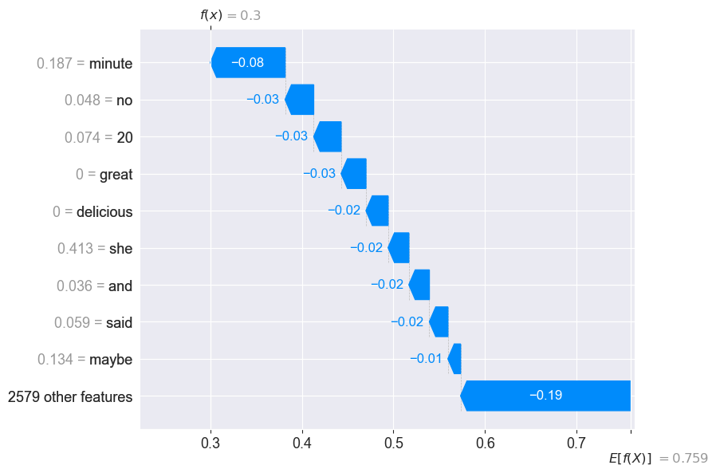

```python
shap.initjs()
ind = 67

print(X_test.iloc[ind])

shap.plots.waterfall(shap_values[ind,:,1])
```

When we look at how the vectorised words in the text affects how the model predicts, we can see here (review nº67, chosen randomly) that there are words like 'minute', '20' or 'no' that help the model to choose the restaurant as non-top experience. Furthermore, if some words do not appear, like great o delicious, induce the model to categorise the experience as non-top as well. In this case, apparently there are no indicators of a top experience, so it can be easily deduced that the restaurant will not be granted as top-experience in the review.

```
If you're looking for an incredible craft beer selection, look no further than Side Bar and Restaurant. The beer on tap are always being updated and they have a huge selection of bottle a well. I also can't recommend their Sunday brunch highly enough. The egg Benedict are perfect every time, not to …
```

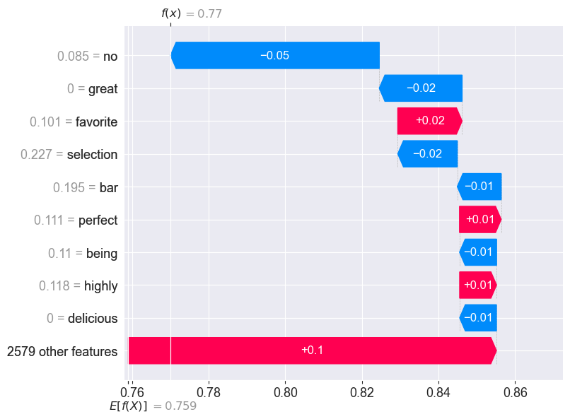

```python
shap.initjs()
ind = 51

print(X_test.iloc[ind])

shap.plots.waterfall(shap_values[ind,:,1])
```

# Graphs

**What is a Graph (Data Structure)?**

A Graph is a non-linear data structure consisting of vertices and edges. The vertices are sometimes also referred to as nodes and the edges are lines or arcs that connect any two nodes in the graph. More formally a Graph is composed of a set of vertices( V ) and a set of edges( E ). The graph is denoted by G(E, V).

**Components of a Graph:**

- Vertices: Vertices are the fundamental units of the graph. Sometimes, vertices are also known as vertex or nodes. Every node/vertex can be labeled or unlabelled.
- Edges: Edges are drawn or used to connect two nodes of the graph. It can be ordered a pair of nodes in a directed graph. Edges can connect any two nodes in any possible way. There are no rules. Sometimes, edges are also known as arcs. Every edge can be labeled/unlabelled.

[figure not shown]

**Graphs in our dataset:**

In this case, we will use Graphs to see the relationship between the words of certain text samples from the customer reviews, so we can figure out how these words are related and hw a SVC model can take them into account and mmake predictions with them.

```python
foodpen_small = foodpen_small.reset_index(drop=True)
```

#### Example 1.

```python
# Vectorising text in reduced dataset
foodpen_sample = foodpen_small.iloc[0:1]
vectorizer = TfidfVectorizer()
small_vectors = vectorizer.fit_transform(foodpen_sample['text_clear'])
```

```python
similarity_scores = cosine_similarity(small_vectors)
```

```
Review: This is nice little Chinese bakery in the heart of Philadelphia's Chinatown! The female cashier wa very friendly (flirtatious!) and the pastry shown in nicely adorned display cases. I stopped by early one evening had a sesame ball, which wa filled with bean paste. The glutinous rice of the b…
```

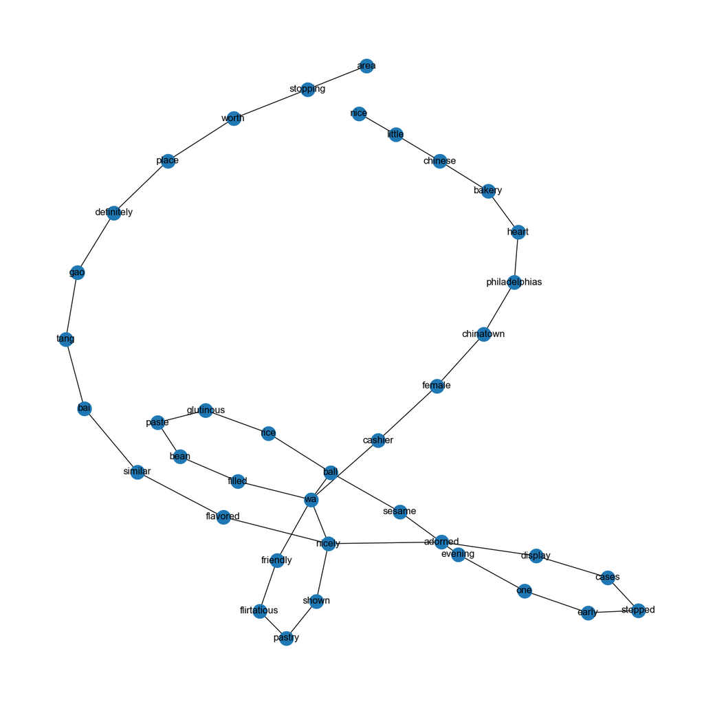

```python
G = nx.Graph()

for i, row in foodpen_sample.iterrows():
    words = row['text_clear'].split()

    for word in words:
        G.add_node(word)

    for j in range(len(words) - 1):
        G.add_edge(words[j], words[j+1])

plt.figure(figsize=(12, 12))

nx.draw(G, pos=nx.spring_layout(G), with_labels=True)

for i, row in foodpen_sample.iterrows():
    print('Review:', row['text'], end='')
    plt.show()
```

In this first sample, which turns to be the first review of the dataset, we can see the conections between the word and how they are related in the text. If the words are located far from the center there's few relationship with the other words. Meanwhile, if they are close, it means they are closely related.

#### Example 2.

```python
# Vectorising text in reduced dataset
foodpen_sample = foodpen_small.iloc[140:141]
from sklearn.feature_extraction.text import TfidfVectorizer
vectorizer = TfidfVectorizer()
small_vectors = vectorizer.fit_transform(foodpen_sample['text_clear'])
```

```python
from sklearn.metrics.pairwise import cosine_similarity
similarity_scores = cosine_similarity(small_vectors)
```

```
Review: Ekta is fantastic. They do everything right. The vegetarian dish are fresh and flavorful, especially the cashew dish with their homemade cheese. The naan is wonderful, chewy, and come in many varieties. The rice pudding is delicious, too. Yum! One of the best place to eat in Bryn Mawr. Very …
```

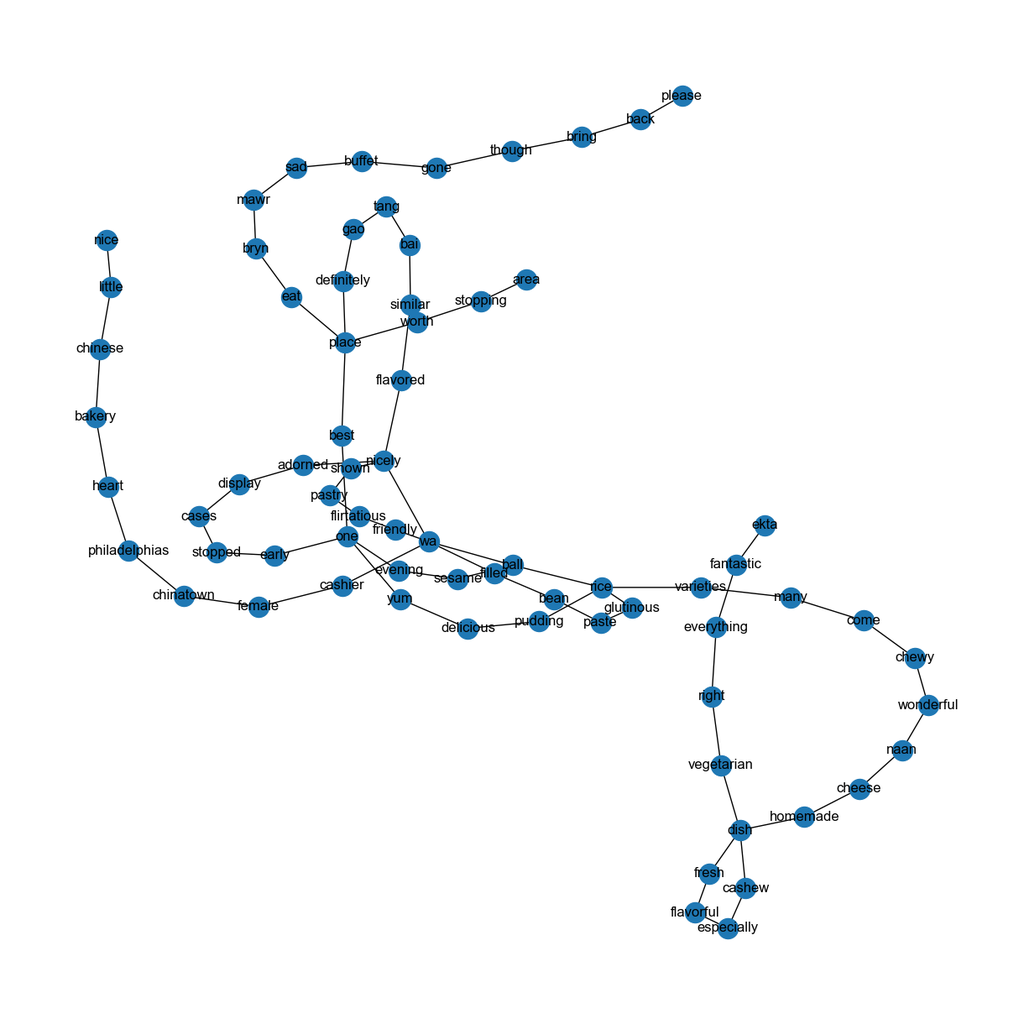

```python
G_2 = nx.Graph()

for i, row in foodpen_sample.iterrows():
    words = row['text_clear'].split()

    for word in words:
        G.add_node(word)

    for j in range(len(words) - 1):
        G.add_edge(words[j], words[j+1])

plt.figure(figsize=(12, 12))

nx.draw(G, pos=nx.spring_layout(G), with_labels=True)

for i, row in foodpen_sample.iterrows():
    print('Review:', row['text'], end='')
    plt.show()
```